# Explore & Summarize Data by Suraag Gupta

This report is for the Financial Contributions to Presidential Campaigns dataset. The state used for this dataset is Ohio.

# Univariate Plots Section

```
## 'data.frame':    167259 obs. of  18 variables:
##  $ cmte_id          : Factor w/ 24 levels "C00458844","C00500587",..: 15 15 15 15 15 6 12 7 6 7 ...
##  $ cand_id          : Factor w/ 24 levels "P00003392","P20002671",..: 23 23 23 23 23 1 15 12 1 12 ...
##  $ cand_nm          : Factor w/ 24 levels "Bush, Jeb","Carson, Benjamin S.",..: 22 22 22 22 22 4 14 19 4 19 ...
##  $ contbr_nm        : Factor w/ 44968 levels "'CALLAHAN, PAMELA",..: 35963 35967 35975 33864 33867 17322 8617 16139 36641 25134 ...
##  $ contbr_city      : Factor w/ 1360 levels " BATAVIA","45320",..: 244 708 248 231 193 274 589 274 596 231 ...
##  $ contbr_st        : Factor w/ 1 level "OH": 1 1 1 1 1 1 1 1 1 1 ...
##  $ contbr_zip       : int  45315 44060 44106 45208 44721 432141210 441071232 432022420 450365038 45249 ...
##  $ contbr_employer  : Factor w/ 13494 levels "","-","(SCHOOL)",..: 5791 9973 5791 1283 10550 5791 3169 8464 9973 10547 ...
##  $ contbr_occupation: Factor w/ 6691 levels "","-"," CERTIFIED REGISTERED NURSE ANESTHETIS",..: 2889 5134 2889 3503 5465 2889 3209 3884 6054 403 ...
##  $ contb_receipt_amt: num  97.1 53.5 69.4 88.4 -80 ...
##  $ contb_receipt_dt : Factor w/ 685 levels "1-Apr-15","1-Apr-16",..: 357 21 199 152 110 69 545 609 452 589 ...
##  $ receipt_desc     : Factor w/ 25 levels ""," SEE REATTRIBUTION",..: 1 1 1 1 1 1 1 1 1 1 ...
##  $ memo_cd          : Factor w/ 2 levels "","X": 2 2 2 2 2 2 1 1 2 1 ...
##  $ memo_text        : Factor w/ 89 levels ""," SEE REATTRIBUTION",..: 1 1 1 1 1 19 1 10 19 10 ...
##  $ form_tp          : Factor w/ 3 levels "SA17A","SA18",..: 2 2 2 2 2 2 1 1 2 1 ...
##  $ file_num         : int  1146165 1146165 1146165 1146165 1146165 1091718 1144564 1077404 1091718 1077404 ...
##  $ tran_id          : Factor w/ 166816 levels "A0000FD2A304E432AAD5",..: 108798 118153 112319 108928 120998 54281 166784 144656 54504 144411 ...
##  $ election_tp      : Factor w/ 4 levels "","G2016","O2016",..: 2 2 2 2 2 4 4 4 4 4 ...
```

There’s almost 170,000 observations in this dataset, with 18 variables. There’s a good chance some of these code blocks will take a fair bit of time to run.

```
##       cmte_id           cand_id                           cand_nm
##  C00575795:71232   P00003392:71232   Clinton, Hillary Rodham  :71232
##  C00577130:34686   P60007168:34686   Sanders, Bernard         :34686
##  C00580100:26873   P80001571:26873   Trump, Donald J.         :26873
##  C00574624:16406   P60006111:16406   Cruz, Rafael Edward 'Ted':16406
##  C00573519: 7937   P60005915: 7937   Carson, Benjamin S.      : 7937
##  C00581876: 4824   P60003670: 4824   Kasich, John R.          : 4824
##  (Other)  : 5301   (Other)  : 5301   (Other)                  : 5301
##                   contbr_nm          contbr_city     contbr_st
##  STOWE, JANICE         :   277   COLUMBUS  : 17469   OH:167259
##  MISSLER, ANDREW J. MR.:   203   CINCINNATI: 15877
##  BRIONES, BERTA        :   179   CLEVELAND :  5821
##  MOESER, DONALD        :   176   DAYTON    :  4716
##  CUMMINGS, JOHN        :   142   TOLEDO    :  3316
##  SCHEEL, PATRICK       :   133   AKRON     :  3239
##  (Other)               :166149   (Other)   :116821
##    contbr_zip                     contbr_employer
##  Min.   :       10   RETIRED              :27810
##  1st Qu.:430829335   N/A                  :22441
##  Median :440741909   SELF-EMPLOYED        : 8590
##  Mean   :362553798   INFORMATION REQUESTED: 8512
##  3rd Qu.:450051586   NONE                 : 7639
##  Max.   :458969665   (Other)              :92136
##  NA's   :3           NA's                 :  131
##              contbr_occupation contb_receipt_amt   contb_receipt_dt
##  RETIRED              :44150   Min.   :-10800.0   11-Jul-16:  2211
##  NOT EMPLOYED         :10397   1st Qu.:    16.0   6-Jul-16 :  2204
##  INFORMATION REQUESTED: 8451   Median :    29.0   12-Jul-16:  1952
##  ATTORNEY             : 3332   Mean   :   119.3   29-Feb-16:  1534
##  HOMEMAKER            : 3245   3rd Qu.:    80.0   12-Aug-16:  1530
##  (Other)              :97662   Max.   : 29100.0   31-Mar-16:  1463
##  NA's                 :   22                      (Other)  :156365
##                      receipt_desc    memo_cd
##                            :165233    :128435
##  Refund                    :   933   X: 38824
##  REDESIGNATION FROM PRIMARY:   211
##  REDESIGNATION TO GENERAL  :   210
##  REATTRIBUTION TO SPOUSE   :   114
##  REATTRIBUTION FROM SPOUSE :   112
##  (Other)                   :   446
##                                memo_text       form_tp
##                                     :117372   SA17A:128696
##  * EARMARKED CONTRIBUTION: SEE BELOW: 33677   SA18 : 37630
##  * HILLARY VICTORY FUND             : 14396   SB28A:   933
##  EARMARKED FROM MAKE DC LISTEN      :   282
##  *BEST EFFORTS UPDATE               :   246
##  REDESIGNATION FROM PRIMARY         :   211
##  (Other)                            :  1075
##     file_num                       tran_id       election_tp
##  Min.   :1003942   A80E77D0E713E417AA88:     3        :   393
##  1st Qu.:1077665   C11887628           :     3   G2016: 59160
##  Median :1099613   C10225661           :     2   O2016:    20
##  Mean   :1101253   C10228611           :     2   P2016:107686
##  3rd Qu.:1133832   C10230213           :     2
##  Max.   :1146285   C10234145           :     2
##                    (Other)             :167245
```

Looking at the summary of the variables, some of my observations are that: - It seems that cmte_id & cand_id are very similar and could possibly have the same semantic references. - Looking at contbr_nm, it seems that several people made contributions multiple times. - All the contributors are in the state of Ohio. - The discrepancies between contbr_employer and contbr_occupation are somewhat strange, as I would expect values such as “RETIRED” to match. - The contribution quantities are fairly small, looking at the mean and median values. The large negative number for the minimum is an interesting data point, I wouldn’t expect there to be negative contributions, or “withdrawals” here. Hopefully, the receipt_desc or memo_text will explain what is going on there.

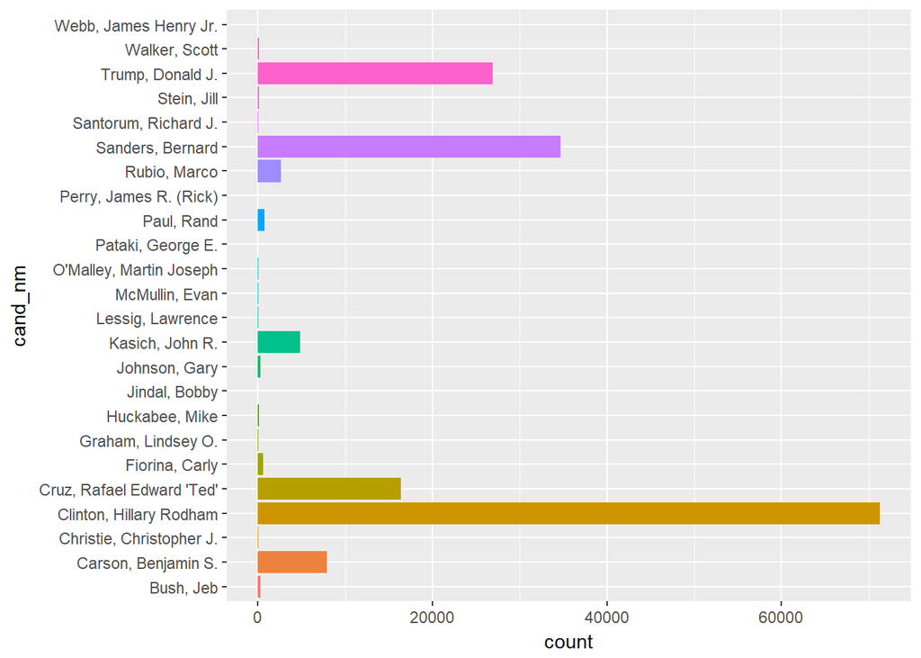

This plot shows quite clearly that the primary recipient of contributions in the state of Ohio was Hilary Clinton, with Bernie Sanders and Trump coming in second & third, respectively, at nearly half the number. Have to keep in mind that this isn’t for the total amount of contributions, just how many times the candidate was contributed to.

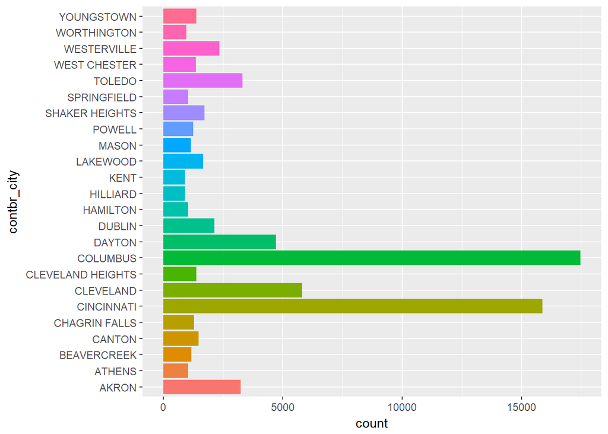

Looking at some of the observations of contbr_city, it quickly becomes clear that the data hasn’t be cleaned, with several misspellings present for the same city. Restricting the plot to cities with higher counts shows what most Ohio residents would expect. Columbus at the top, with Cincinnati close behind.

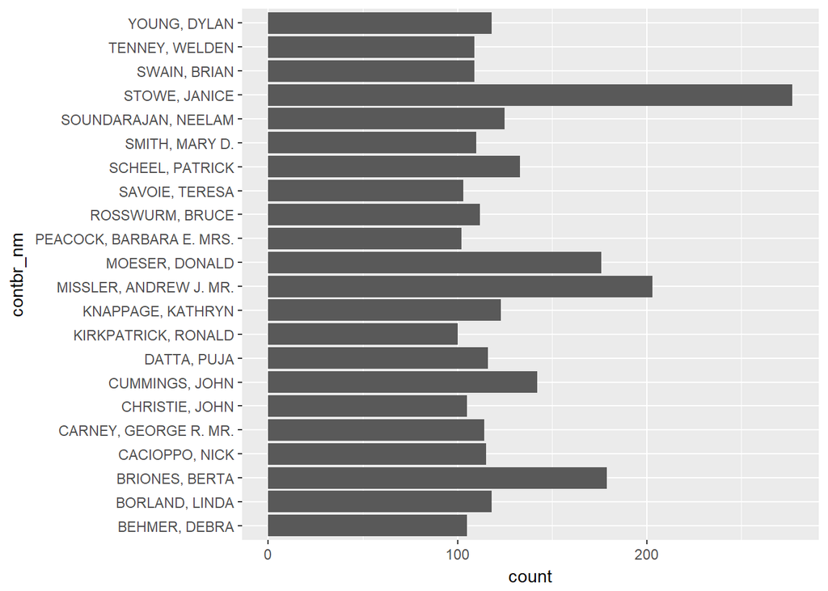

Somewhat unexpected to see people contributing so many times. The main question that arises here is who out of these people will appear on the highest amount plot.

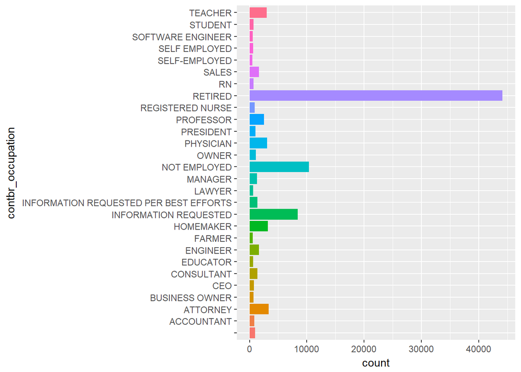

I wasn’t expecting to see the Retired contributors make up such a significant portion of the dataset, this should be interesting to investigate soon.

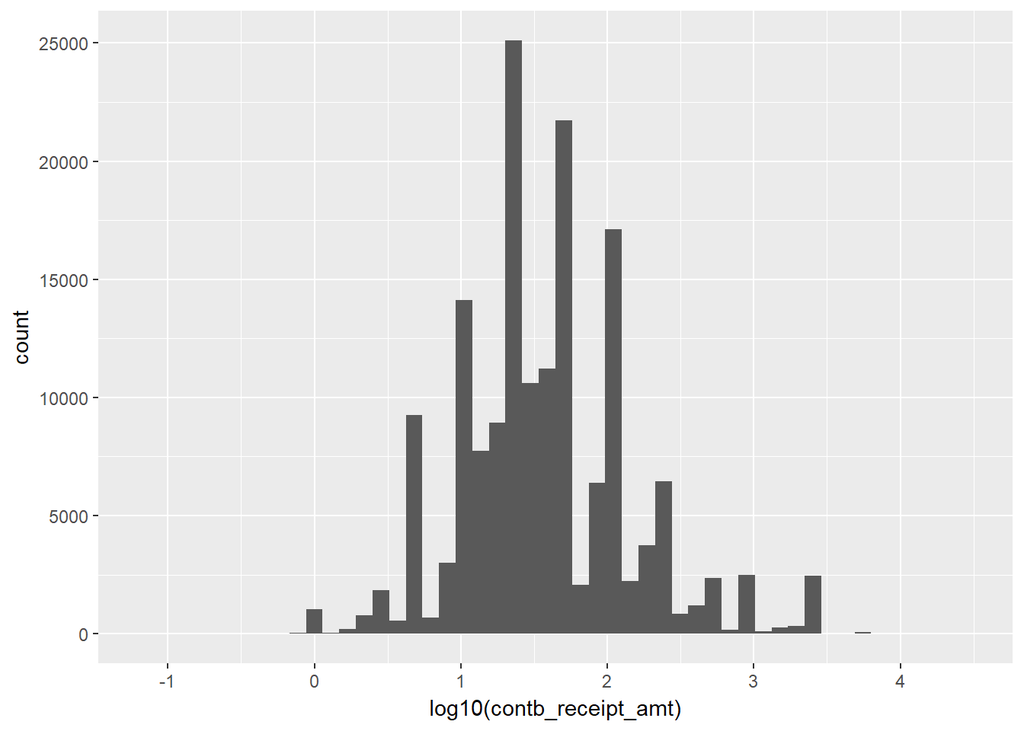

Here I used a log10 for the contribution amounts here to visualize better. The majority of donations seem to be between the $10 to $100 range.

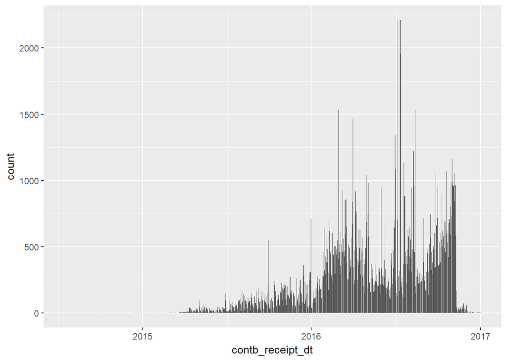

As would be expected here, most of the contributions were made in in the year of the election, with the majority coming in what appears to be near the middle or end of the summer.

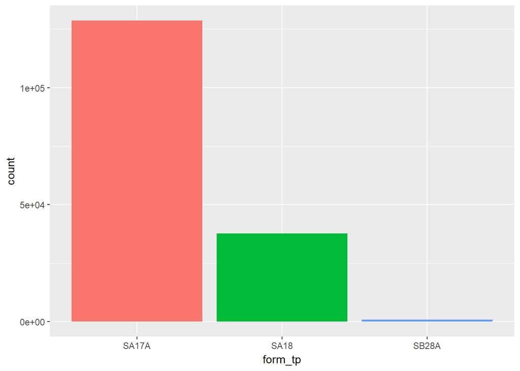

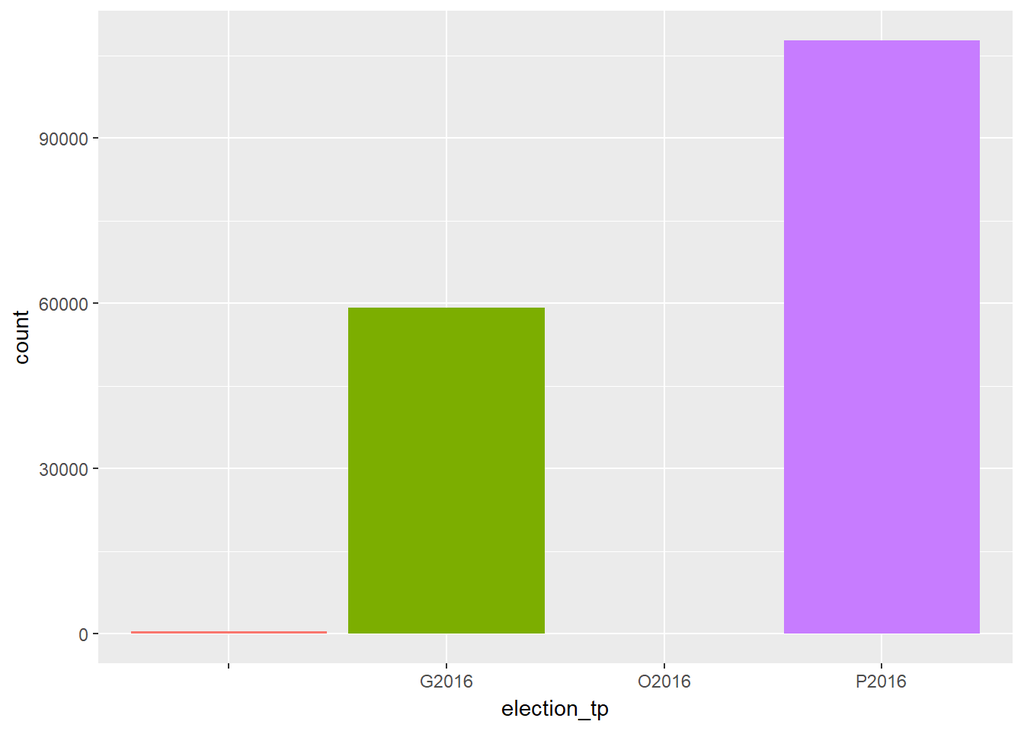

Most of the contributions are directed towards the general & presidential elections.

# Univariate Analysis

### What is the structure of your dataset?

The Financial Contributions dataset for Ohio has 167,259 observations of 18 variables. Committee ID, Candidate ID, & Candidate Name seem to refer to the same pieces of data. Most of the variables are unordered factors, due to being names, locations, or reference IDs.

### What is/are the main feature(s) of interest in your dataset?

I think the main features of the dataset are the candidates & the contribution amounts.

### What other features in the dataset do you think will help support your investigation into your feature(s) of interest?

Supporting the above two features would be the contribution dates/the election type & the occupation of the contributors. ### Did you create any new variables from existing variables in the dataset? I created new dataframes for the first three plots, so that I could have an easier time subsetting the data based on counts.

### Of the features you investigated, were there any unusual distributions? Did you perform any operations on the data to tidy, adjust, or change the form of the data? If so, why did you do this?

There were misspellings in the contributor city, zip code, employer, & occupation features, but I did not attempt to fix these. I changed the receipt dates from Strings to Dates to make calculations and plots involving them easier.

# Bivariate Plots Section

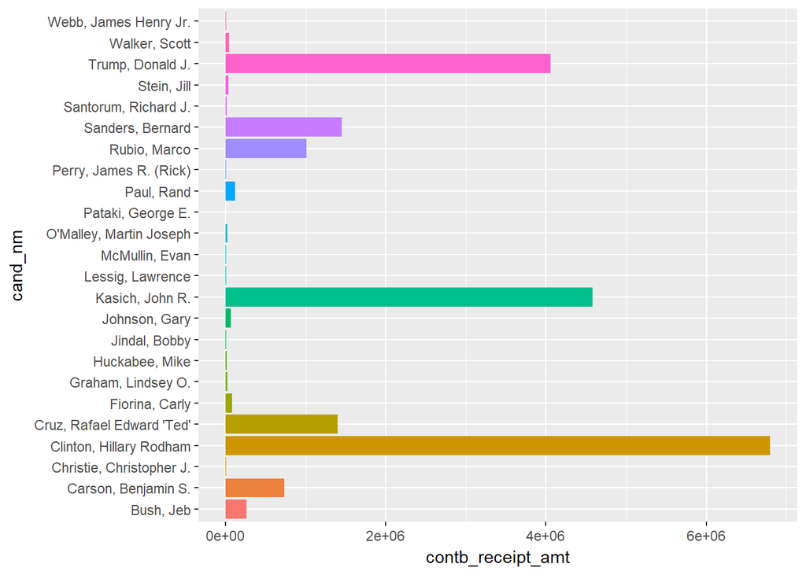

In line with the contribution counts, Hillary Clinton maintains the highest total contribution value, but unexpectedly, John Kasich has a surprisingly high contribution value ranking at 2nd, while only having the 6th highest contribution count. This could indicate the types of voters/contributors that supported him. Similarly, Bernie & Trump switched roles with counts & amounts.

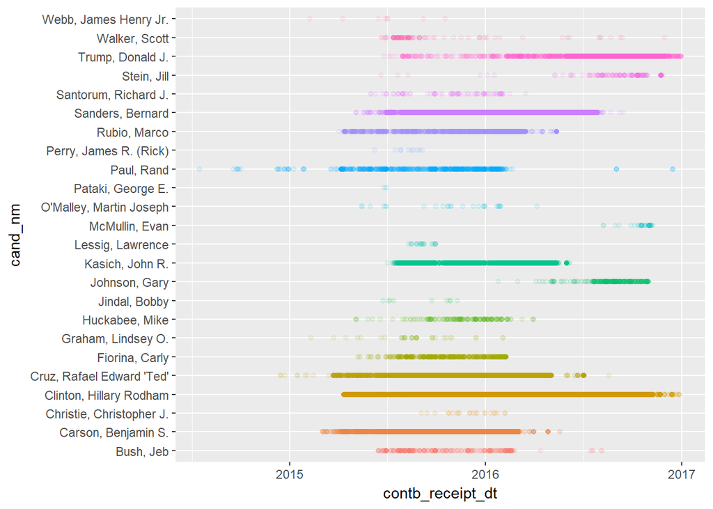

Here we see that contributions towards the primary elections lasted for a long while, and consisted of most of the contributions, which is in line with the earlier plot of election type counts.

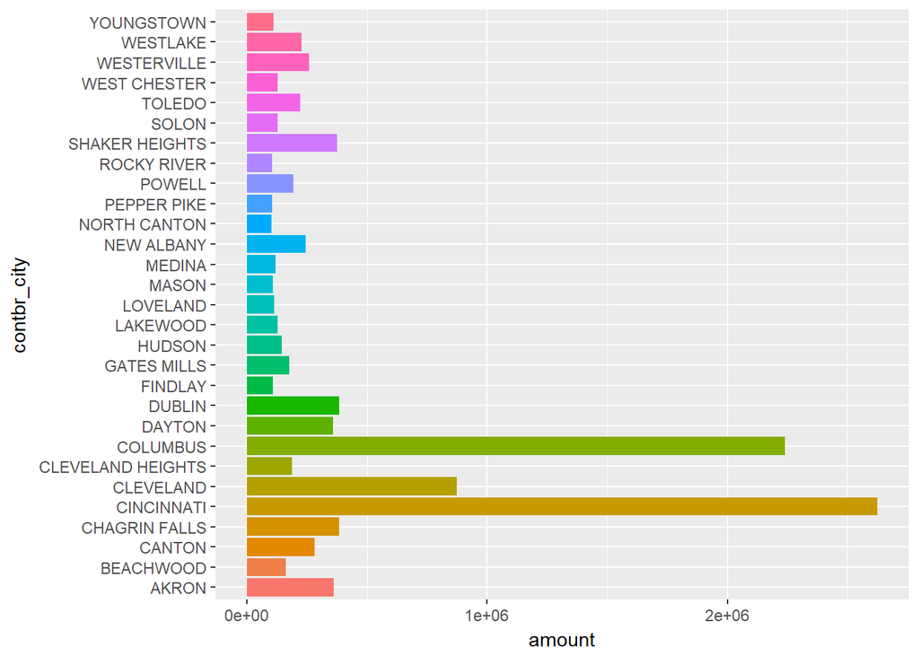

Slightly unexpectedly, while Columbus may have had the highest number of contributors, Cincinnati had a higher contribution value.

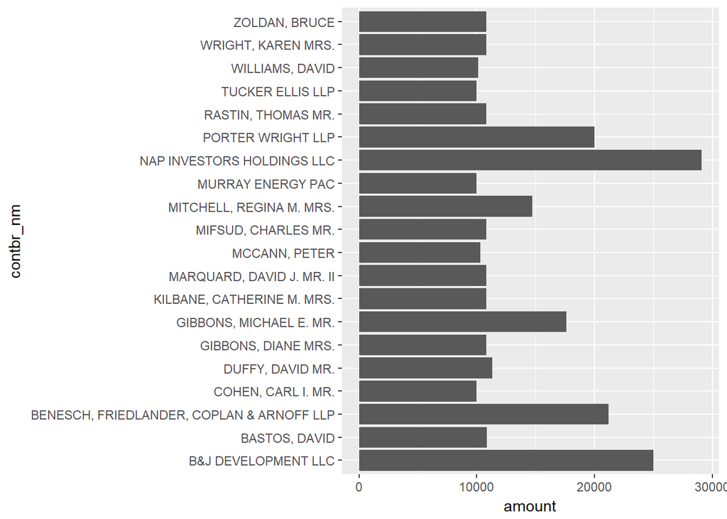

Comparing this plot to that of the one with the highest contribution counts, there are no matching names. It’s possible that contributors will either make multiple small contributions over a period of time or they will make a few large contributions.

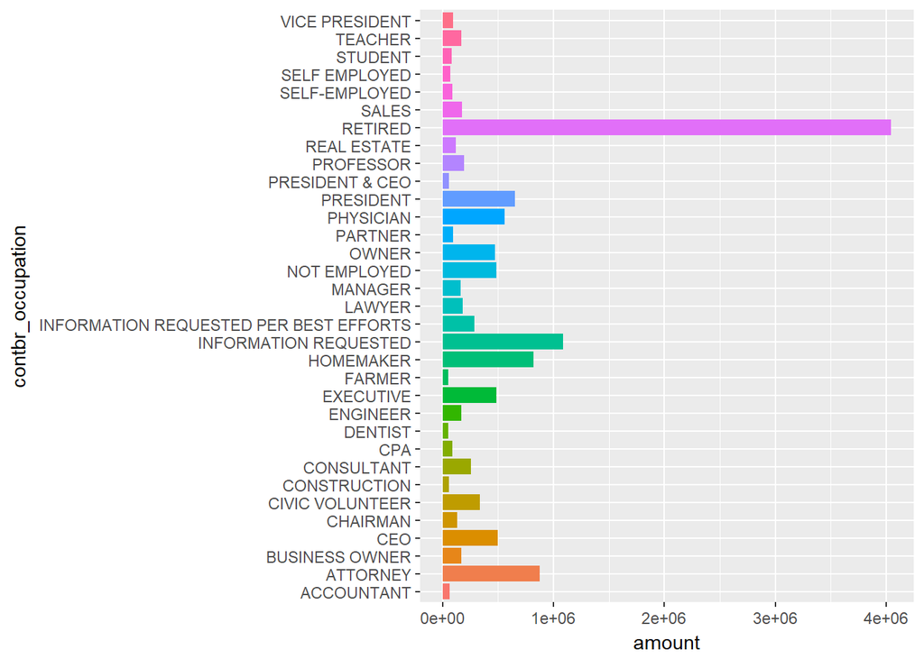

Moving on to the occupations of the contributors, retirees still take the prime position with donation amounts, that too by a huge margin.

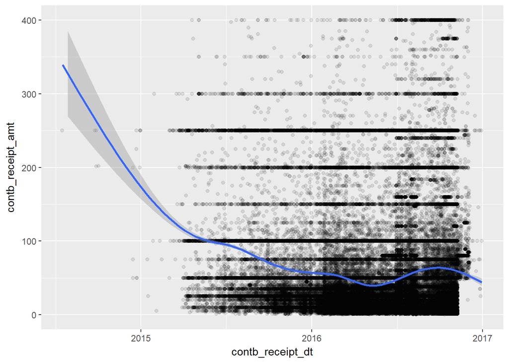

Using the 95% quantile for the contribution amounts and cutting out the negatives, which after doing some exploration seemed to be mostly refunds, it seems that most of the contributions came as the election itself approached.

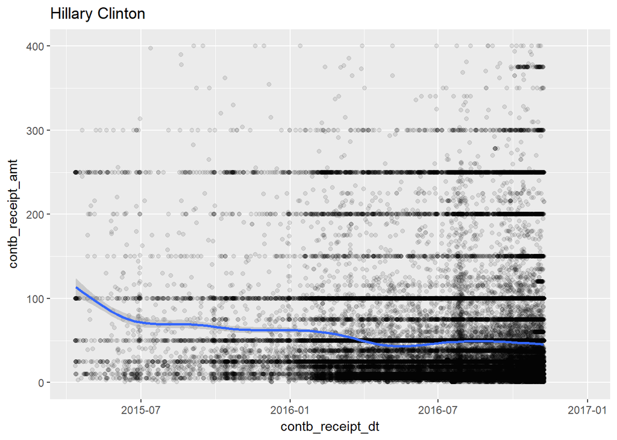

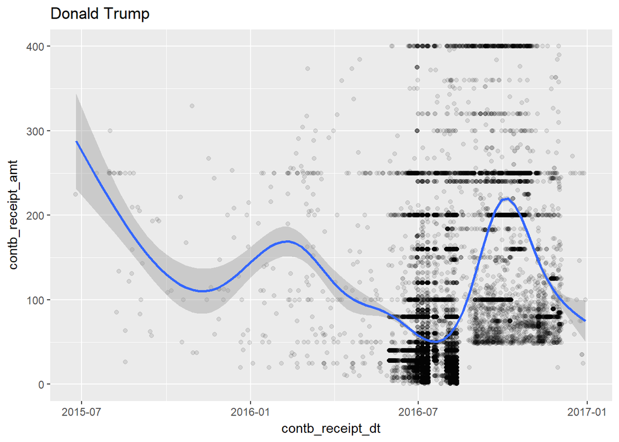

Two interesting things can be seen in this plot. First, most of the contributions are larger in value, as only a small chunk of the plot has values less than about $50. Second, contributions to Trump continued even after he won.

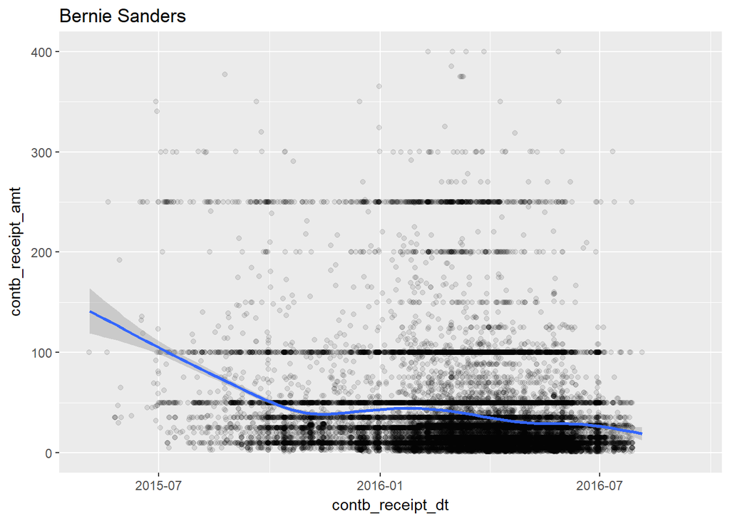

The above plots for the top 3 contributed candidates have similar trends. Few contributions made in the year prior to the election, but generally of higher value, while the year of the election is where most of the data lies.

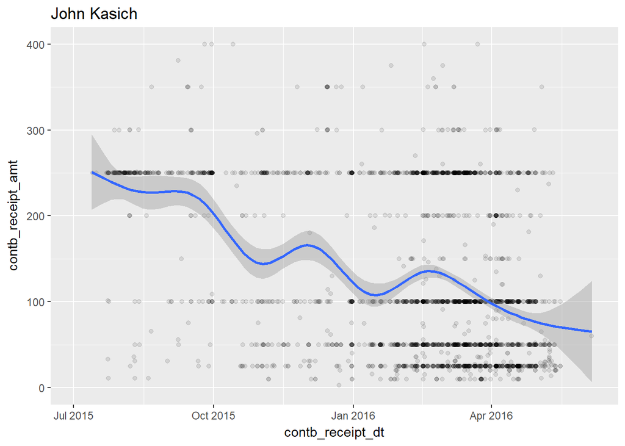

This plot is fairly different from the previous 3. While the information is all gathered in a shorter time frame, it seems that, compared to the other candidates, there are few contributors that donated less than $50, with the majority of the values seeming to be at $100 or $250.

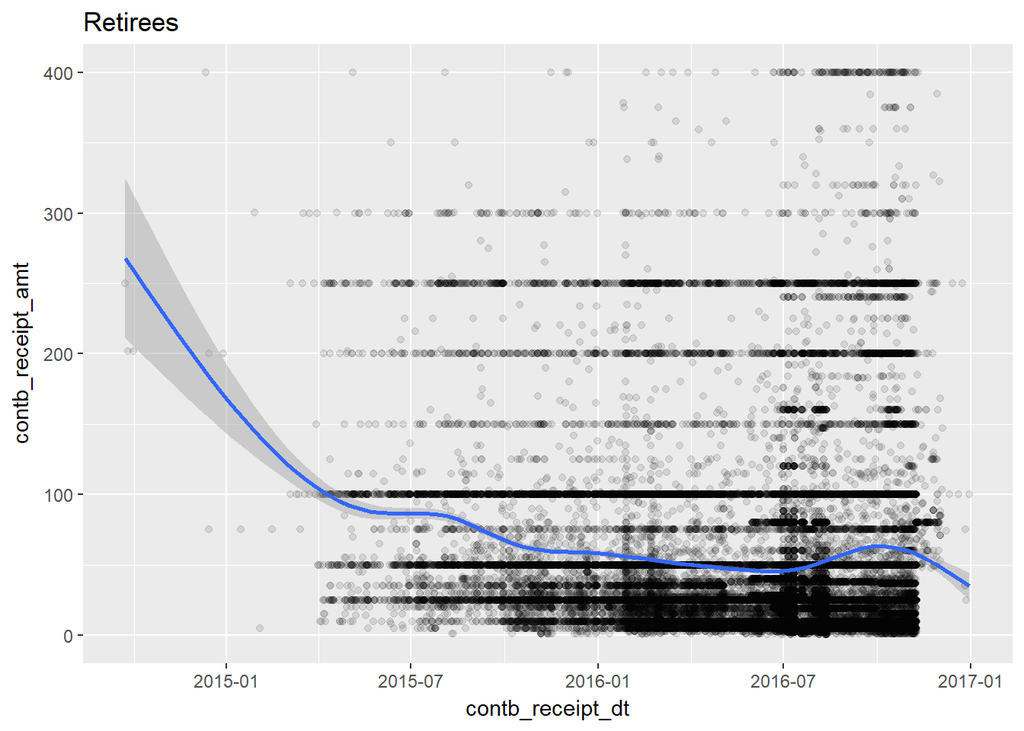

A similar situation with the individual candidates is visible with the retired contributors. This trend is likely identical with all candidates and contributor occupations.

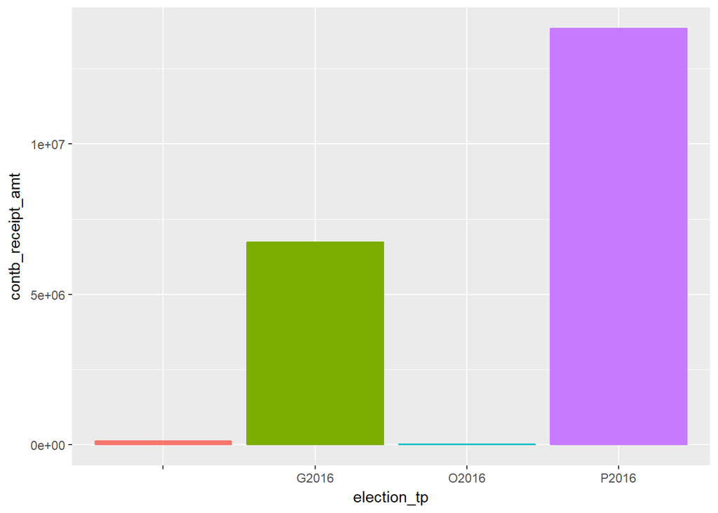

The contribution amounts based on the election are in line with the contribution counts, with the majority of it going towards the primary election.

# Bivariate Analysis

### Talk about some of the relationships you observed in this part of the investigation. How did the feature(s) of interest vary with other features in the dataset?

Overall, the contribution amounts and contribution counts produced similar relationships through the dataset, with only a few notable exceptions that were pointed out above.

### Did you observe any interesting relationships between the other features (not the main feature(s) of interest)?

One of the main factors I observed was the date variable. Depending on when the candidates were no longer considered in the running, contributions either completely stopped or slowed down significantly. The amount of contributions increased closer to the election, while the amount of the contribution didn’t seem to be directly affected by the date.

### What was the strongest relationship you found?

It seems that the strongest relationship is between date and amount.

# Multivariate Plots Section

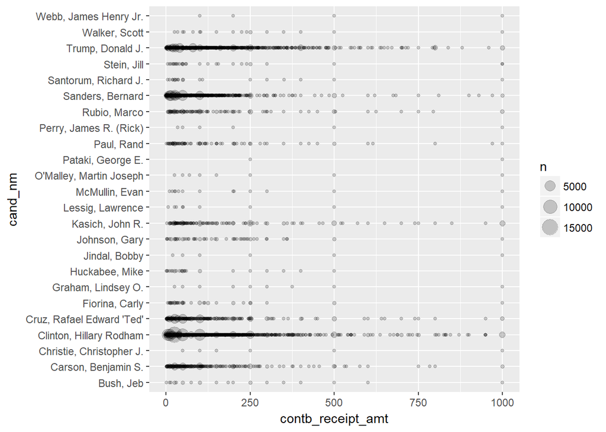

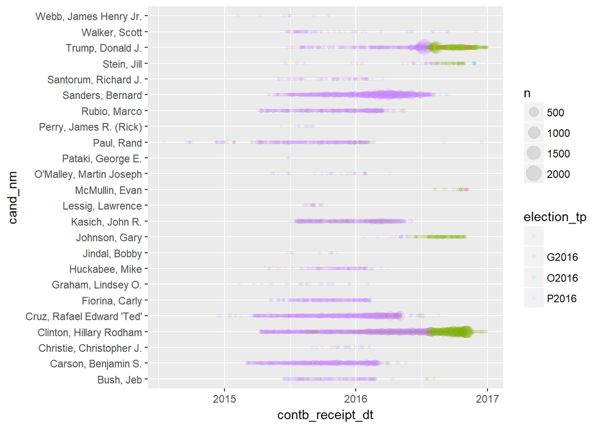

# Multivariate Analysis

### Talk about some of the relationships you observed in this part of the investigation. Were there features that strengthened each other in terms of looking at your feature(s) of interest?

The first multivariate plot created reinforced the smaller contribution values at higher quantities. The second plot illustrated how the funds were split for particular elections.

### Were there any interesting or surprising interactions between features?

The second plot, with the candidates vs the contribution dates colorized by the election type was expected, but still somewhat interesting to see. As the candidates lost in the primary elections, their funds disappeared, and for the winners, all the funding went directly to the coming general election. It’s likely that this is just a sorting and organizational detail made by the committee, as the contributors would not need to make the specification as to which election the funds went toward.

# Final Plots and Summary

### Plot One

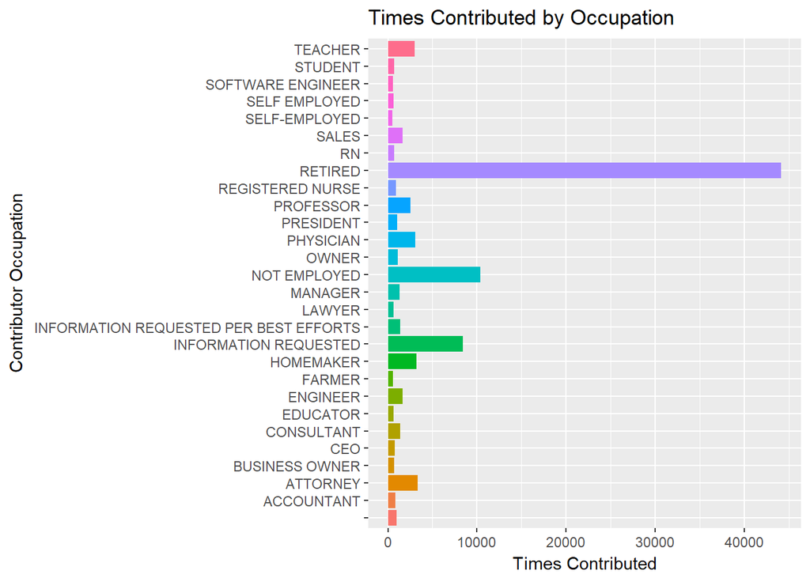

### Description One

I thought this plot was interesting because I didn’t expect retirees to make up such a huge portion of the contributors.

### Plot Two

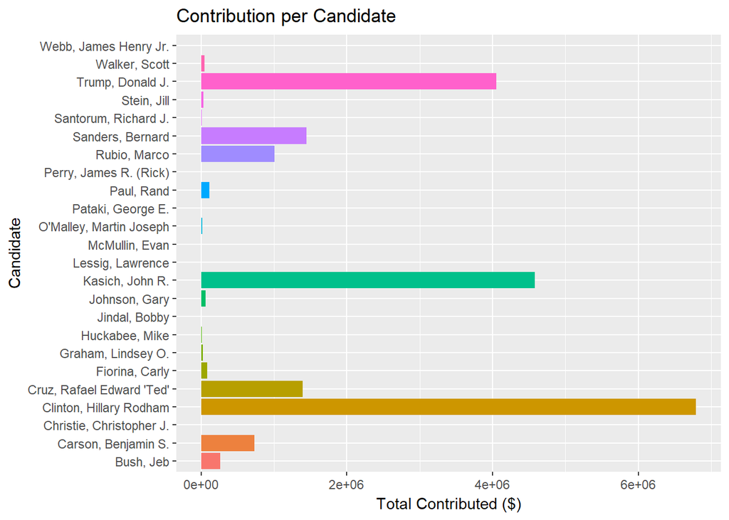

### Description Two

This plot is interesting because it demonstrates that even with a much larger amount of financial support, the top 2 candidates here lost the election. It would be interesting to see if there were similar situations in previous election years, as Donald Trump has a significant amount of wealth on his own, which may have also been a factor in his relatively lower amount of contribution.

### Plot Three

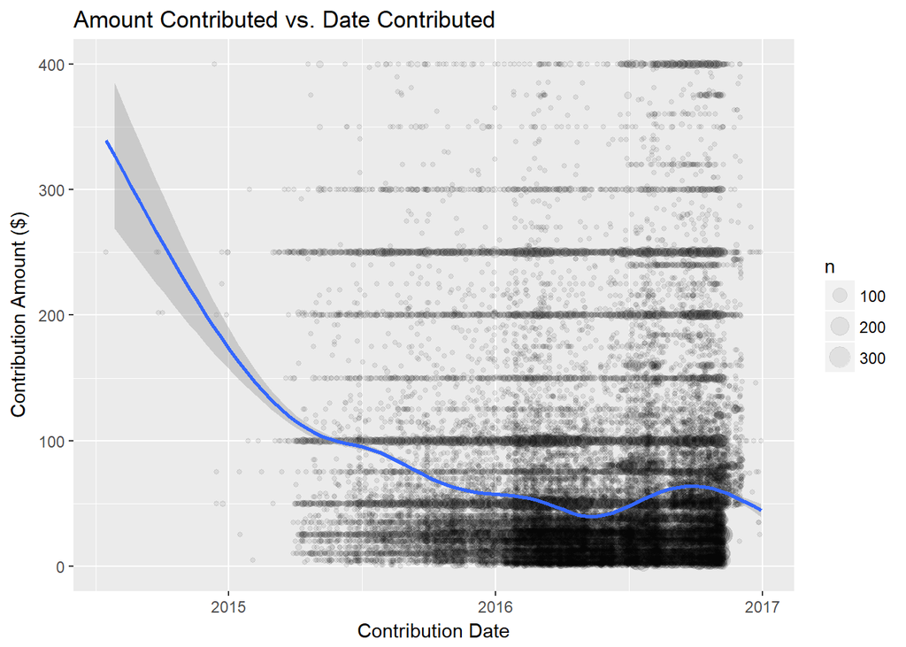

### Description Three

Perhaps the most obvious of the three plots, showing that the bulk of the contributions came in closer to the date of the general election. ——

# Reflection

I was slightly disappointed with what information there was to find in this dataset. While the insights and plots created certainly had a good amount of information to share, there weren’t as many variables to explore as I would have liked. In addition, with the sheer quantity of different contributors, cities, occupations, & employers, it was a little hard to explore everything as much as I would have liked. There may be more insights to discover using smaller subsets based on the contributors, cities, and occupations, after cleaning the data and having a better method to split up the information and plots that rely on factored variables.